# Getting and Cleaning Data Course Project

Franco Corona

2021-05-09

## Reference: https://rubenarslan.github.io/codebook/articles/codebook.html

Running run_analysis.R file:

The data was processed by run_analysis.R

```
## No missing values.
```

### Metadata

#### Description

**Dataset name**: Human Activity Recognition Using Smartphones Dataset

a small analysis by Franco Corona

**Metadata for search engines**

- **Temporal Coverage**: 2021
- **Spatial Coverage**: Mexico city, México
- **Citation**: Franco Corona, Getting and Cleaning Data Course Project
- **URL**: https://github.com/exibios/ds_jh_m3_w4
- **Identifier**: MX-001
- **Date published**: 2021-05-09
- **Creator**:

| name | value |
| --- | --- |
| @type | Person |
| givenName | Franco |
| familyName | Corona |
| email | exibios@gmail.com |
| affiliation | Coursera , Data Science Specialization by Johns Hopkins University- Mexico city |

| x |
| --- |
| activity_name |
| subject |
| tBodyAcc-mean()-X |
| tBodyAcc-mean()-Y |
| tBodyAcc-mean()-Z |
| tBodyAcc-std()-X |
| tBodyAcc-std()-Y |
| tBodyAcc-std()-Z |
| tGravityAcc-mean()-X |
| tGravityAcc-mean()-Y |
| tGravityAcc-mean()-Z |
| tGravityAcc-std()-X |
| tGravityAcc-std()-Y |
| tGravityAcc-std()-Z |
| tBodyAccJerk-mean()-X |
| tBodyAccJerk-mean()-Y |
| tBodyAccJerk-mean()-Z |
| tBodyAccJerk-std()-X |
| tBodyAccJerk-std()-Y |
| tBodyAccJerk-std()-Z |
| tBodyGyro-mean()-X |
| tBodyGyro-mean()-Y |
| tBodyGyro-mean()-Z |
| tBodyGyro-std()-X |
| tBodyGyro-std()-Y |
| tBodyGyro-std()-Z |
| tBodyGyroJerk-mean()-X |
| tBodyGyroJerk-mean()-Y |
| tBodyGyroJerk-mean()-Z |
| tBodyGyroJerk-std()-X |

[output cut: 51 more lines]

#Variables

### activity_name

#### Distribution

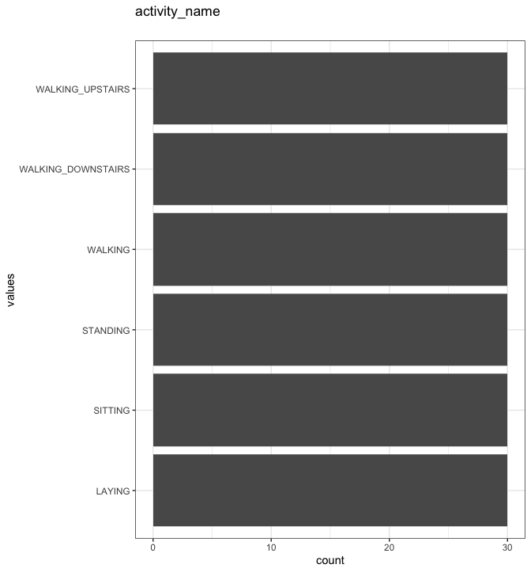

Distribution of values for activity_name

0 missing values.

#### Summary statistics

| name | data_type | n_missing | complete_rate | n_unique | empty | min | max | whitespace | label |
| --- | --- | --- | --- | --- | --- | --- | --- | --- | --- |
| activity_name | character | 0 | 1 | 6 | 0 | 6 | 18 | 0 | NA |

### subject

#### Distribution

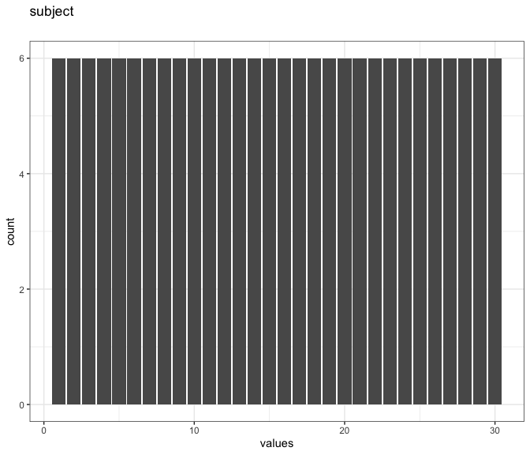

Distribution of values for subject

0 missing values.

#### Summary statistics

| name | data_type | n_missing | complete_rate | min | median | max | mean | sd | hist | label |
| --- | --- | --- | --- | --- | --- | --- | --- | --- | --- | --- |
| subject | numeric | 0 | 1 | 1 | 16 | 30 | 15.5 | 8.679585 | ▇▇▇▇▇ | NA |

### tBodyAcc-mean()-X

#### Distribution

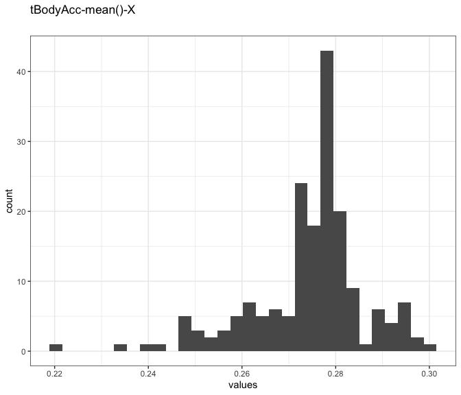

Distribution of values for tBodyAcc-mean()-X

0 missing values.

#### Summary statistics

| name | data_type | n_missing | complete_rate | min | median | max | mean | sd | hist | label |
| --- | --- | --- | --- | --- | --- | --- | --- | --- | --- | --- |
| tBodyAcc-mean()-X | numeric | 0 | 1 | 0.22 | 0.28 | 0.3 | 0.2743027 | 0.0121646 | ▁▁▂▇▂ | NA |

### tBodyAcc-mean()-Y

#### Distribution

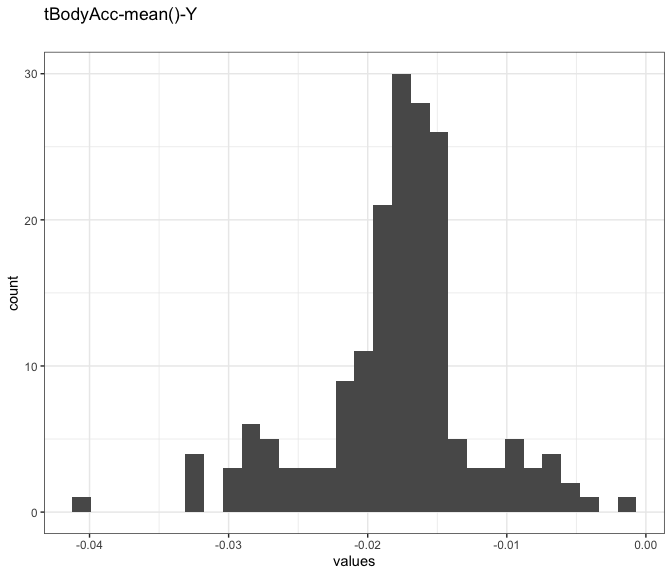

Distribution of values for tBodyAcc-mean()-Y

0 missing values.

#### Summary statistics

| name | data_type | n_missing | complete_rate | min | median | max | mean | sd | hist | label |
| --- | --- | --- | --- | --- | --- | --- | --- | --- | --- | --- |
| tBodyAcc-mean()-Y | numeric | 0 | 1 | -0.041 | -0.017 | -0.0013 | -0.0178755 | 0.0057712 | ▁▂▇▇▁ | NA |

### tBodyAcc-mean()-Z

#### Distribution

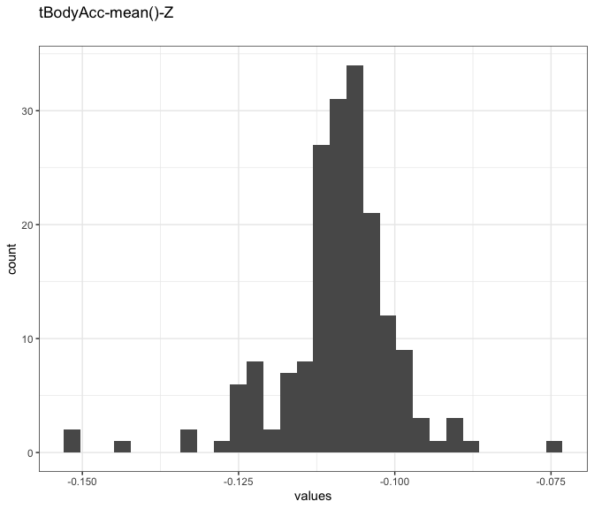

Distribution of values for tBodyAcc-mean()-Z

0 missing values.

#### Summary statistics

| name | data_type | n_missing | complete_rate | min | median | max | mean | sd | hist | label |
| --- | --- | --- | --- | --- | --- | --- | --- | --- | --- | --- |
| tBodyAcc-mean()-Z | numeric | 0 | 1 | -0.15 | -0.11 | -0.075 | -0.1091638 | 0.009582 | ▁▁▇▅▁ | NA |

### tBodyAcc-std()-X

#### Distribution

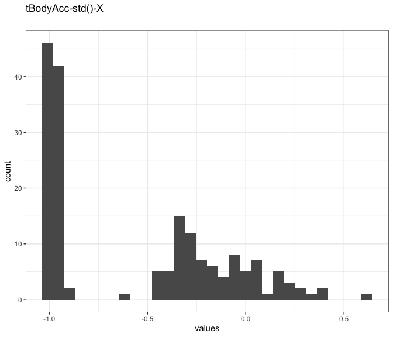

Distribution of values for tBodyAcc-std()-X

0 missing values.

#### Summary statistics

| name | data_type | n_missing | complete_rate | min | median | max | mean | sd | hist | label |
| --- | --- | --- | --- | --- | --- | --- | --- | --- | --- | --- |
| tBodyAcc-std()-X | numeric | 0 | 1 | -1 | -0.75 | 0.63 | -0.5576901 | 0.4516911 | ▇▂▅▂▁ | NA |

### tBodyAcc-std()-Y

#### Distribution

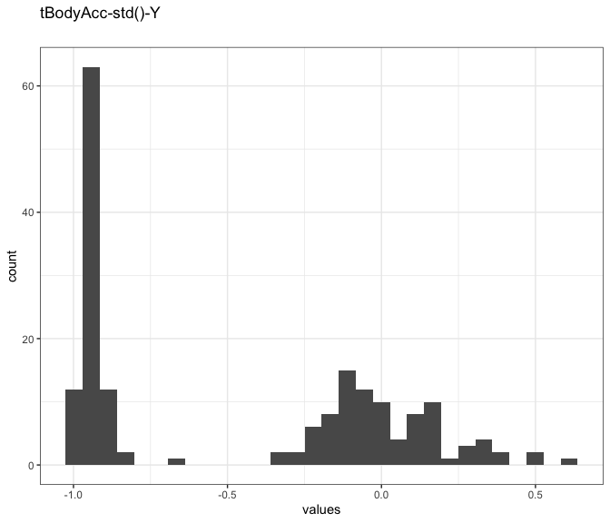

Distribution of values for tBodyAcc-std()-Y

0 missing values.

#### Summary statistics

| name | data_type | n_missing | complete_rate | min | median | max | mean | sd | hist | label |
| --- | --- | --- | --- | --- | --- | --- | --- | --- | --- | --- |
| tBodyAcc-std()-Y | numeric | 0 | 1 | -0.99 | -0.51 | 0.62 | -0.4604626 | 0.496565 | ▇▁▅▃▁ | NA |

### tBodyAcc-std()-Z

#### Distribution

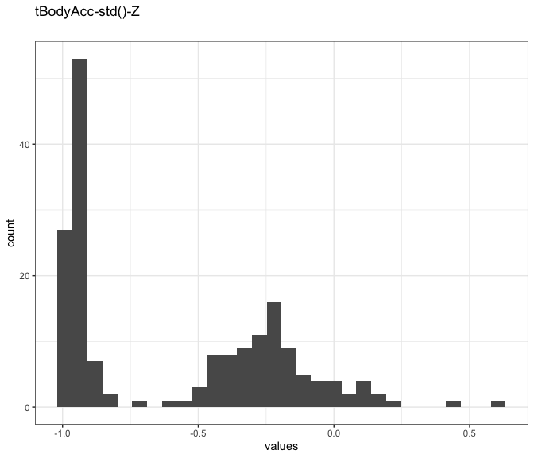

Distribution of values for tBodyAcc-std()-Z

0 missing values.

#### Summary statistics

| name | data_type | n_missing | complete_rate | min | median | max | mean | sd | hist | label |
| --- | --- | --- | --- | --- | --- | --- | --- | --- | --- | --- |
| tBodyAcc-std()-Z | numeric | 0 | 1 | -0.99 | -0.65 | 0.61 | -0.5755602 | 0.3955439 | ▇▂▅▁▁ | NA |

### tGravityAcc-mean()-X

#### Distribution

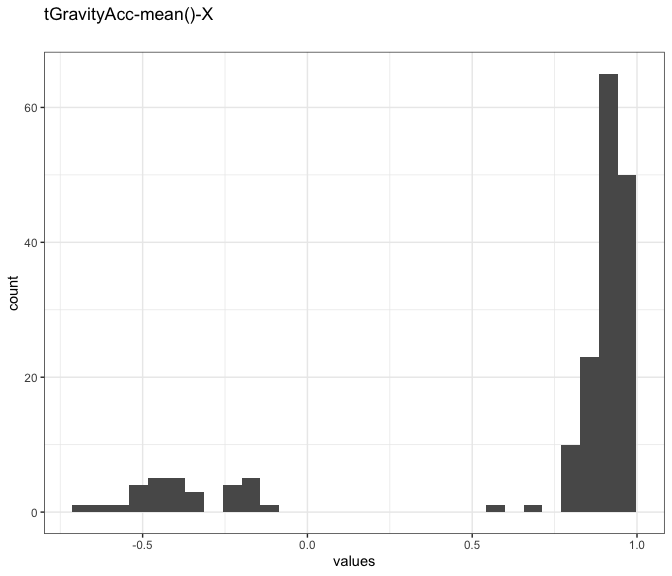

Distribution of values for tGravityAcc-mean()-X

0 missing values.

#### Summary statistics

| name | data_type | n_missing | complete_rate | min | median | max | mean | sd | hist | label |
| --- | --- | --- | --- | --- | --- | --- | --- | --- | --- | --- |
| tGravityAcc-mean()-X | numeric | 0 | 1 | -0.68 | 0.92 | 0.97 | 0.6974775 | 0.4872534 | ▁▁▁▁▇ | NA |

### tGravityAcc-mean()-Y

#### Distribution

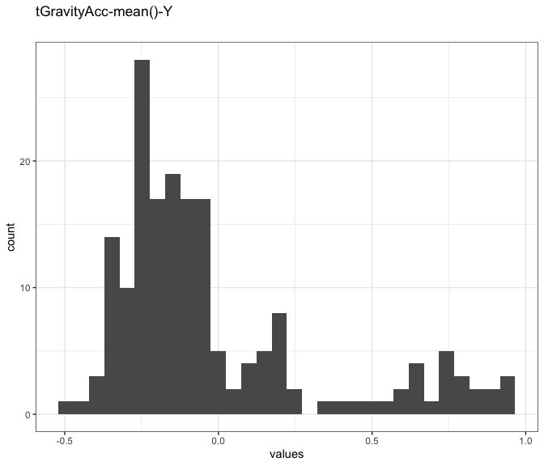

Distribution of values for tGravityAcc-mean()-Y

0 missing values.

#### Summary statistics

| name | data_type | n_missing | complete_rate | min | median | max | mean | sd | hist | label |
| --- | --- | --- | --- | --- | --- | --- | --- | --- | --- | --- |
| tGravityAcc-mean()-Y | numeric | 0 | 1 | -0.48 | -0.13 | 0.96 | -0.0162128 | 0.3452376 | ▇▇▂▁▂ | NA |

### tGravityAcc-mean()-Z

#### Distribution

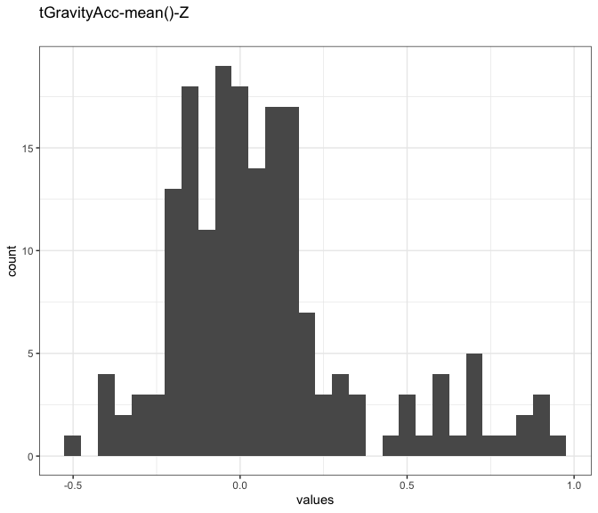

Distribution of values for tGravityAcc-mean()-Z

0 missing values.

#### Summary statistics

| name | data_type | n_missing | complete_rate | min | median | max | mean | sd | hist | label |
| --- | --- | --- | --- | --- | --- | --- | --- | --- | --- | --- |
| tGravityAcc-mean()-Z | numeric | 0 | 1 | -0.5 | 0.024 | 0.96 | 0.0741279 | 0.2887919 | ▂▇▃▁▁ | NA |

### tGravityAcc-std()-X

#### Distribution

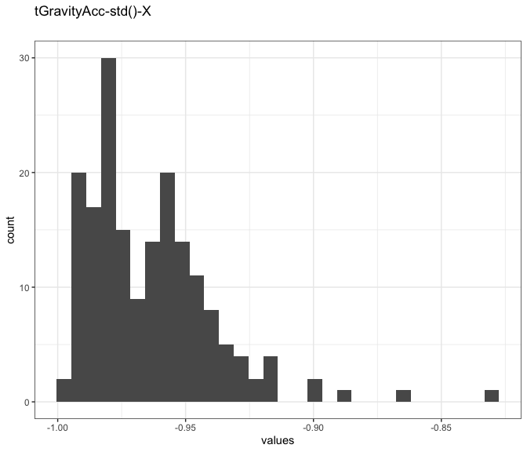

Distribution of values for tGravityAcc-std()-X

0 missing values.

#### Summary statistics

| name | data_type | n_missing | complete_rate | min | median | max | mean | sd | hist | label |
| --- | --- | --- | --- | --- | --- | --- | --- | --- | --- | --- |
| tGravityAcc-std()-X | numeric | 0 | 1 | -1 | -0.97 | -0.83 | -0.9637525 | 0.0250344 | ▇▆▁▁▁ | NA |

### tGravityAcc-std()-Y

#### Distribution

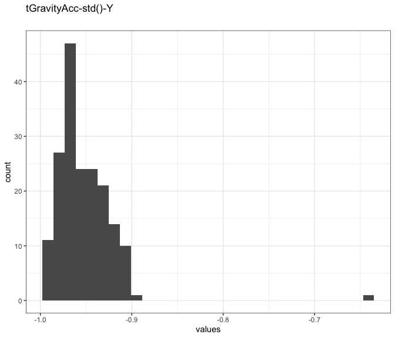

Distribution of values for tGravityAcc-std()-Y

0 missing values.

#### Summary statistics

| name | data_type | n_missing | complete_rate | min | median | max | mean | sd | hist | label |
| --- | --- | --- | --- | --- | --- | --- | --- | --- | --- | --- |
| tGravityAcc-std()-Y | numeric | 0 | 1 | -0.99 | -0.96 | -0.64 | -0.9524296 | 0.0326557 | ▇▁▁▁▁ | NA |

### tGravityAcc-std()-Z

#### Distribution

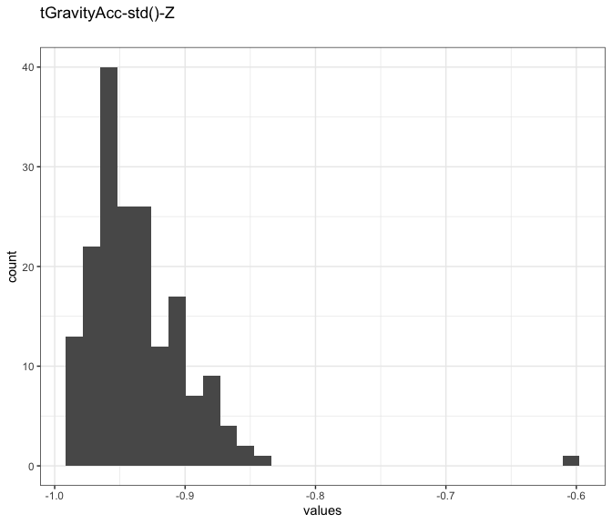

Distribution of values for tGravityAcc-std()-Z

0 missing values.

#### Summary statistics

| name | data_type | n_missing | complete_rate | min | median | max | mean | sd | hist | label |
| --- | --- | --- | --- | --- | --- | --- | --- | --- | --- | --- |
| tGravityAcc-std()-Z | numeric | 0 | 1 | -0.99 | -0.95 | -0.61 | -0.936401 | 0.0402912 | ▇▂▁▁▁ | NA |

### tBodyAccJerk-mean()-X

#### Distribution

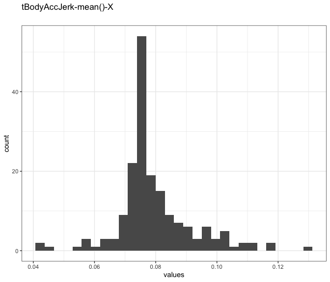

Distribution of values for tBodyAccJerk-mean()-X

0 missing values.

#### Summary statistics

| name | data_type | n_missing | complete_rate | min | median | max | mean | sd | hist | label |
| --- | --- | --- | --- | --- | --- | --- | --- | --- | --- | --- |
| tBodyAccJerk-mean()-X | numeric | 0 | 1 | 0.043 | 0.076 | 0.13 | 0.0794736 | 0.012588 | ▁▇▃▂▁ | NA |

### tBodyAccJerk-mean()-Y

#### Distribution

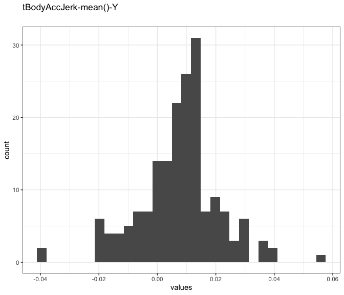

Distribution of values for tBodyAccJerk-mean()-Y

0 missing values.

#### Summary statistics

| name | data_type | n_missing | complete_rate | min | median | max | mean | sd | hist | label |
| --- | --- | --- | --- | --- | --- | --- | --- | --- | --- | --- |
| tBodyAccJerk-mean()-Y | numeric | 0 | 1 | -0.039 | 0.0095 | 0.057 | 0.0075652 | 0.0135764 | ▁▃▇▂▁ | NA |

### tBodyAccJerk-mean()-Z

#### Distribution

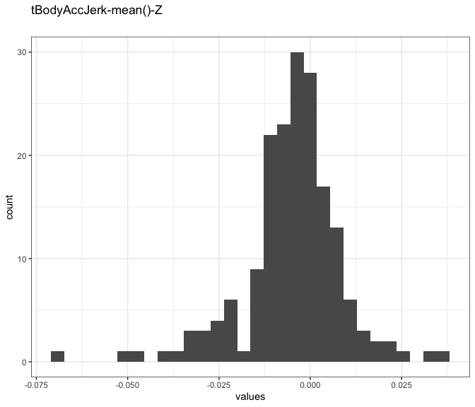

Distribution of values for tBodyAccJerk-mean()-Z

0 missing values.

#### Summary statistics

| name | data_type | n_missing | complete_rate | min | median | max | mean | sd | hist | label |
| --- | --- | --- | --- | --- | --- | --- | --- | --- | --- | --- |
| tBodyAccJerk-mean()-Z | numeric | 0 | 1 | -0.067 | -0.0039 | 0.038 | -0.0049534 | 0.0134621 | ▁▁▇▇▁ | NA |

### tBodyAccJerk-std()-X

#### Distribution

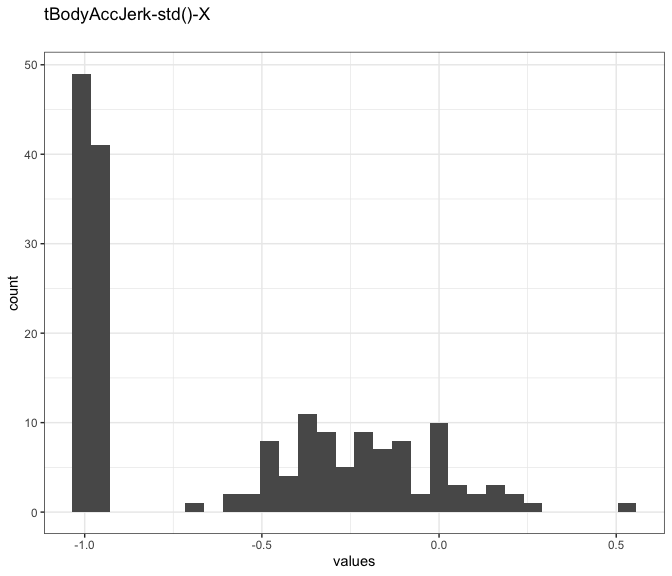

Distribution of values for tBodyAccJerk-std()-X

0 missing values.

#### Summary statistics

| name | data_type | n_missing | complete_rate | min | median | max | mean | sd | hist | label |
| --- | --- | --- | --- | --- | --- | --- | --- | --- | --- | --- |
| tBodyAccJerk-std()-X | numeric | 0 | 1 | -0.99 | -0.81 | 0.54 | -0.5949467 | 0.4175865 | ▇▂▅▂▁ | NA |

### tBodyAccJerk-std()-Y

#### Distribution

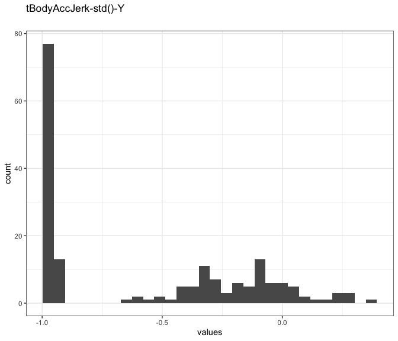

Distribution of values for tBodyAccJerk-std()-Y

0 missing values.

#### Summary statistics

| name | data_type | n_missing | complete_rate | min | median | max | mean | sd | hist | label |
| --- | --- | --- | --- | --- | --- | --- | --- | --- | --- | --- |
| tBodyAccJerk-std()-Y | numeric | 0 | 1 | -0.99 | -0.78 | 0.36 | -0.5654147 | 0.4330871 | ▇▁▃▃▁ | NA |

### tBodyAccJerk-std()-Z

#### Distribution

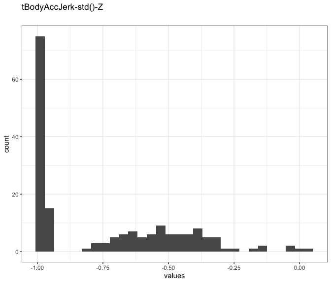

Distribution of values for tBodyAccJerk-std()-Z

0 missing values.

#### Summary statistics

| name | data_type | n_missing | complete_rate | min | median | max | mean | sd | hist | label |
| --- | --- | --- | --- | --- | --- | --- | --- | --- | --- | --- |
| tBodyAccJerk-std()-Z | numeric | 0 | 1 | -0.99 | -0.88 | 0.031 | -0.7359577 | 0.2768479 | ▇▂▃▁▁ | NA |

### tBodyGyro-mean()-X

#### Distribution

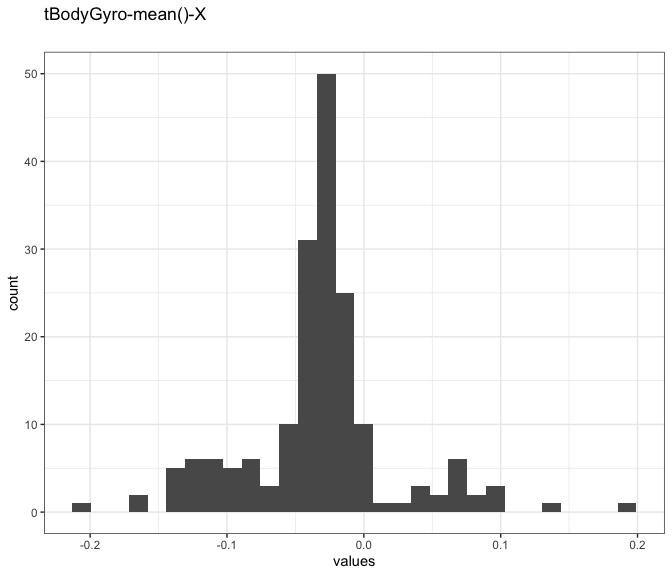

Distribution of values for tBodyGyro-mean()-X

0 missing values.

#### Summary statistics

| name | data_type | n_missing | complete_rate | min | median | max | mean | sd | hist | label |
| --- | --- | --- | --- | --- | --- | --- | --- | --- | --- | --- |
| tBodyGyro-mean()-X | numeric | 0 | 1 | -0.21 | -0.029 | 0.19 | -0.0324372 | 0.0540518 | ▁▂▇▁▁ | NA |

### tBodyGyro-mean()-Y

#### Distribution

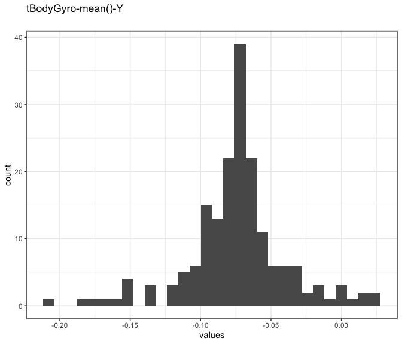

Distribution of values for tBodyGyro-mean()-Y

0 missing values.

#### Summary statistics

| name | data_type | n_missing | complete_rate | min | median | max | mean | sd | hist | label |
| --- | --- | --- | --- | --- | --- | --- | --- | --- | --- | --- |
| tBodyGyro-mean()-Y | numeric | 0 | 1 | -0.2 | -0.073 | 0.027 | -0.0742596 | 0.0355415 | ▁▁▇▃▁ | NA |

### tBodyGyro-mean()-Z

#### Distribution

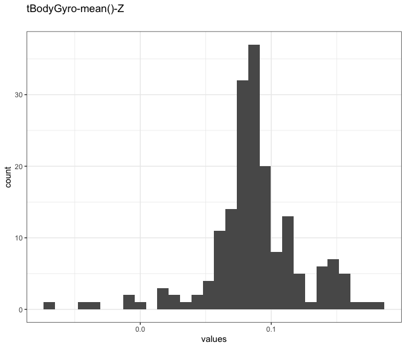

Distribution of values for tBodyGyro-mean()-Z

0 missing values.

#### Summary statistics

| name | data_type | n_missing | complete_rate | min | median | max | mean | sd | hist | label |
| --- | --- | --- | --- | --- | --- | --- | --- | --- | --- | --- |
| tBodyGyro-mean()-Z | numeric | 0 | 1 | -0.072 | 0.085 | 0.18 | 0.0874446 | 0.0362125 | ▁▁▃▇▂ | NA |

### tBodyGyro-std()-X

#### Distribution

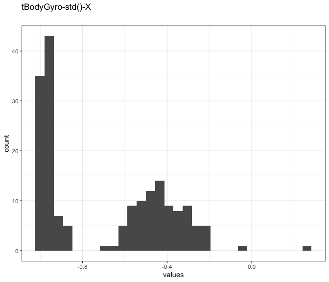

Distribution of values for tBodyGyro-std()-X

0 missing values.

#### Summary statistics

| name | data_type | n_missing | complete_rate | min | median | max | mean | sd | hist | label |
| --- | --- | --- | --- | --- | --- | --- | --- | --- | --- | --- |
| tBodyGyro-std()-X | numeric | 0 | 1 | -0.99 | -0.79 | 0.27 | -0.6916399 | 0.2910189 | ▇▃▅▁▁ | NA |

### tBodyGyro-std()-Y

#### Distribution

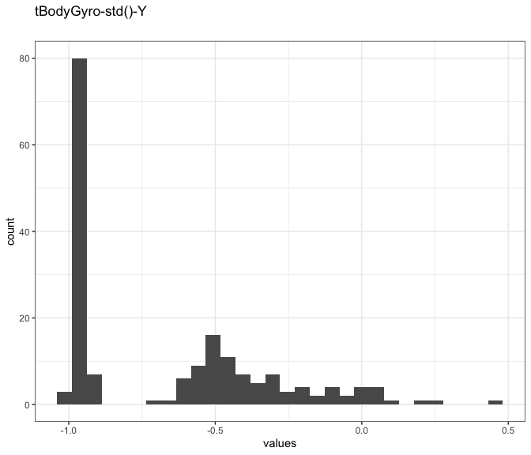

Distribution of values for tBodyGyro-std()-Y

0 missing values.

#### Summary statistics

| name | data_type | n_missing | complete_rate | min | median | max | mean | sd | hist | label |
| --- | --- | --- | --- | --- | --- | --- | --- | --- | --- | --- |
| tBodyGyro-std()-Y | numeric | 0 | 1 | -0.99 | -0.8 | 0.48 | -0.653302 | 0.3520252 | ▇▅▂▁▁ | NA |

### tBodyGyro-std()-Z

#### Distribution

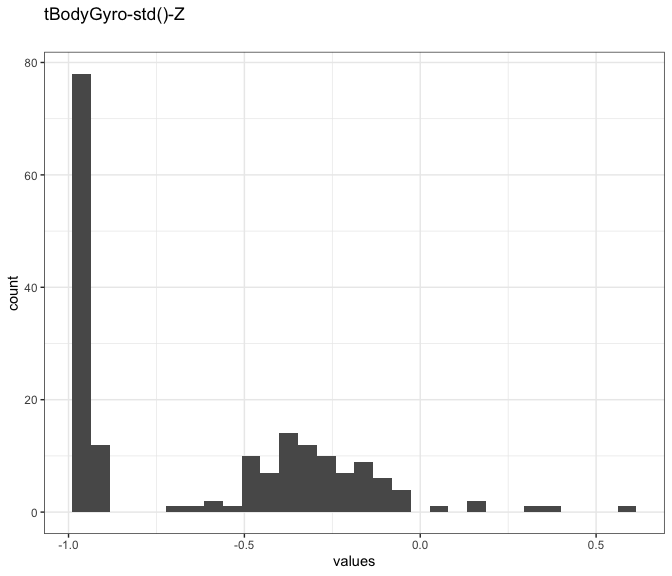

Distribution of values for tBodyGyro-std()-Z

0 missing values.

#### Summary statistics

| name | data_type | n_missing | complete_rate | min | median | max | mean | sd | hist | label |
| --- | --- | --- | --- | --- | --- | --- | --- | --- | --- | --- |
| tBodyGyro-std()-Z | numeric | 0 | 1 | -0.99 | -0.8 | 0.56 | -0.6164353 | 0.3730264 | ▇▂▅▁▁ | NA |

### tBodyGyroJerk-mean()-X

#### Distribution

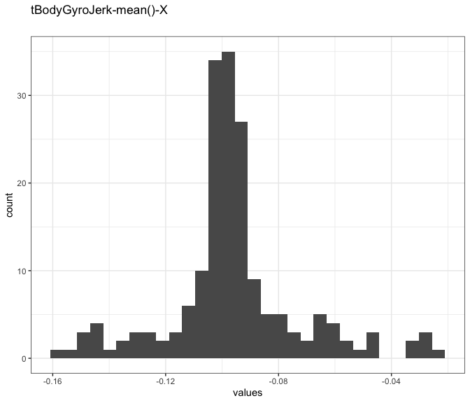

Distribution of values for tBodyGyroJerk-mean()-X

0 missing values.

#### Summary statistics

| name | data_type | n_missing | complete_rate | min | median | max | mean | sd | hist | label |
| --- | --- | --- | --- | --- | --- | --- | --- | --- | --- | --- |
| tBodyGyroJerk-mean()-X | numeric | 0 | 1 | -0.16 | -0.099 | -0.022 | -0.0960568 | 0.0233458 | ▁▂▇▁▁ | NA |

### tBodyGyroJerk-mean()-Y

#### Distribution

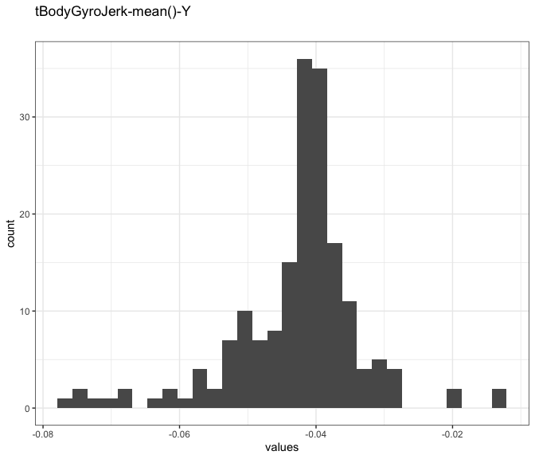

Distribution of values for tBodyGyroJerk-mean()-Y

0 missing values.

#### Summary statistics

| name | data_type | n_missing | complete_rate | min | median | max | mean | sd | hist | label |
| --- | --- | --- | --- | --- | --- | --- | --- | --- | --- | --- |
| tBodyGyroJerk-mean()-Y | numeric | 0 | 1 | -0.077 | -0.041 | -0.013 | -0.0426928 | 0.009532 | ▁▂▇▃▁ | NA |

### tBodyGyroJerk-mean()-Z

#### Distribution

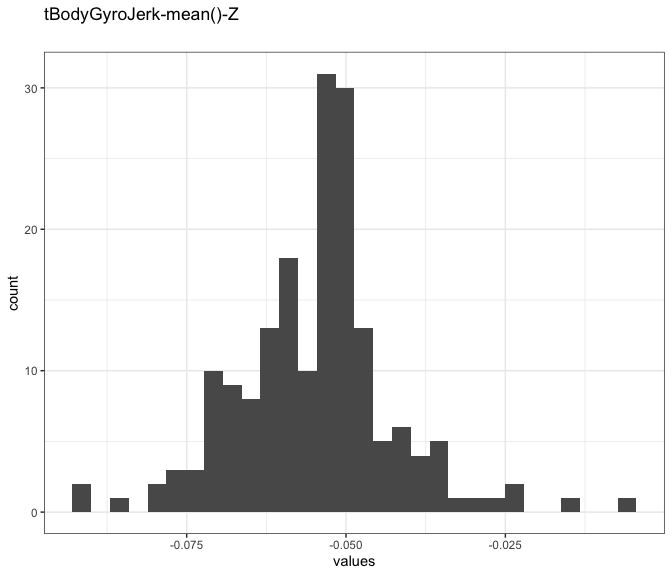

Distribution of values for tBodyGyroJerk-mean()-Z

0 missing values.

#### Summary statistics

| name | data_type | n_missing | complete_rate | min | median | max | mean | sd | hist | label |
| --- | --- | --- | --- | --- | --- | --- | --- | --- | --- | --- |
| tBodyGyroJerk-mean()-Z | numeric | 0 | 1 | -0.092 | -0.053 | -0.0069 | -0.0548019 | 0.012347 | ▁▅▇▁▁ | NA |

### tBodyGyroJerk-std()-X

#### Distribution

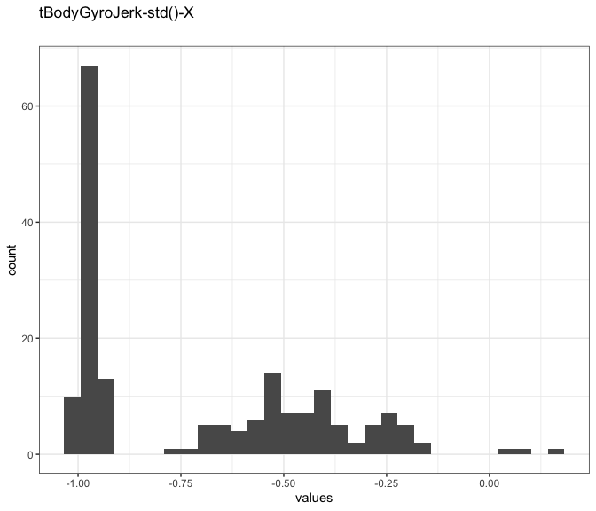

Distribution of values for tBodyGyroJerk-std()-X

0 missing values.

#### Summary statistics

| name | data_type | n_missing | complete_rate | min | median | max | mean | sd | hist | label |
| --- | --- | --- | --- | --- | --- | --- | --- | --- | --- | --- |
| tBodyGyroJerk-std()-X | numeric | 0 | 1 | -1 | -0.84 | 0.18 | -0.7036327 | 0.3008361 | ▇▂▃▂▁ | NA |

### tBodyGyroJerk-std()-Y

#### Distribution

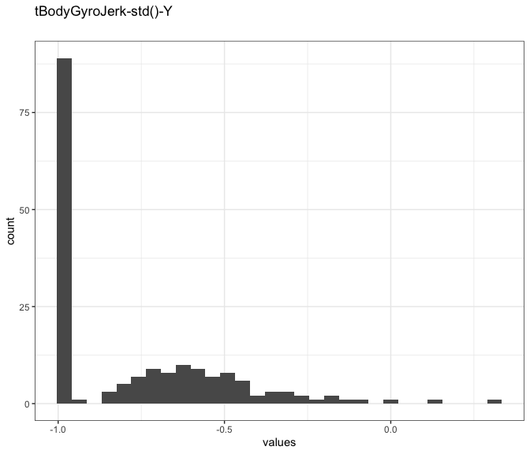

Distribution of values for tBodyGyroJerk-std()-Y

0 missing values.

#### Summary statistics

| name | data_type | n_missing | complete_rate | min | median | max | mean | sd | hist | label |
| --- | --- | --- | --- | --- | --- | --- | --- | --- | --- | --- |
| tBodyGyroJerk-std()-Y | numeric | 0 | 1 | -1 | -0.89 | 0.3 | -0.7635518 | 0.2672885 | ▇▃▂▁▁ | NA |

### tBodyGyroJerk-std()-Z

#### Distribution

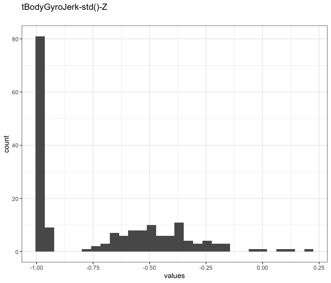

Distribution of values for tBodyGyroJerk-std()-Z

0 missing values.

#### Summary statistics

| name | data_type | n_missing | complete_rate | min | median | max | mean | sd | hist | label |
| --- | --- | --- | --- | --- | --- | --- | --- | --- | --- | --- |
| tBodyGyroJerk-std()-Z | numeric | 0 | 1 | -1 | -0.86 | 0.19 | -0.7095592 | 0.3045394 | ▇▃▃▁▁ | NA |

### tBodyAccMag-mean()

#### Distribution

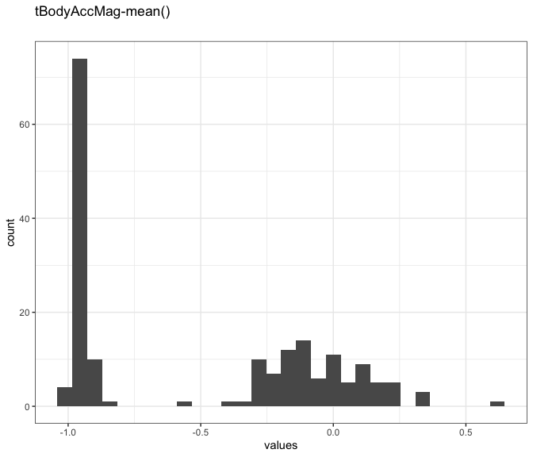

Distribution of values for tBodyAccMag-mean()

0 missing values.

#### Summary statistics

| name | data_type | n_missing | complete_rate | min | median | max | mean | sd | hist | label |
| --- | --- | --- | --- | --- | --- | --- | --- | --- | --- | --- |
| tBodyAccMag-mean() | numeric | 0 | 1 | -0.99 | -0.48 | 0.64 | -0.4972897 | 0.4728834 | ▇▁▅▃▁ | NA |

### tBodyAccMag-std()

#### Distribution

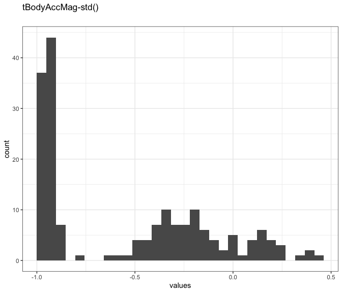

Distribution of values for tBodyAccMag-std()

0 missing values.

#### Summary statistics

| name | data_type | n_missing | complete_rate | min | median | max | mean | sd | hist | label |
| --- | --- | --- | --- | --- | --- | --- | --- | --- | --- | --- |
| tBodyAccMag-std() | numeric | 0 | 1 | -0.99 | -0.61 | 0.43 | -0.5439087 | 0.4310448 | ▇▁▅▂▁ | NA |

### tGravityAccMag-mean()

#### Distribution

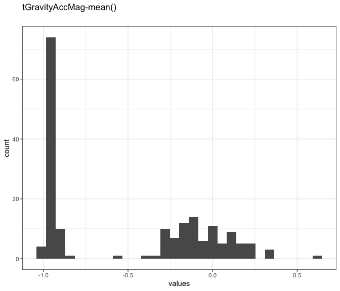

Distribution of values for tGravityAccMag-mean()

0 missing values.

#### Summary statistics

| name | data_type | n_missing | complete_rate | min | median | max | mean | sd | hist | label |
| --- | --- | --- | --- | --- | --- | --- | --- | --- | --- | --- |
| tGravityAccMag-mean() | numeric | 0 | 1 | -0.99 | -0.48 | 0.64 | -0.4972897 | 0.4728834 | ▇▁▅▃▁ | NA |

### tGravityAccMag-std()

#### Distribution

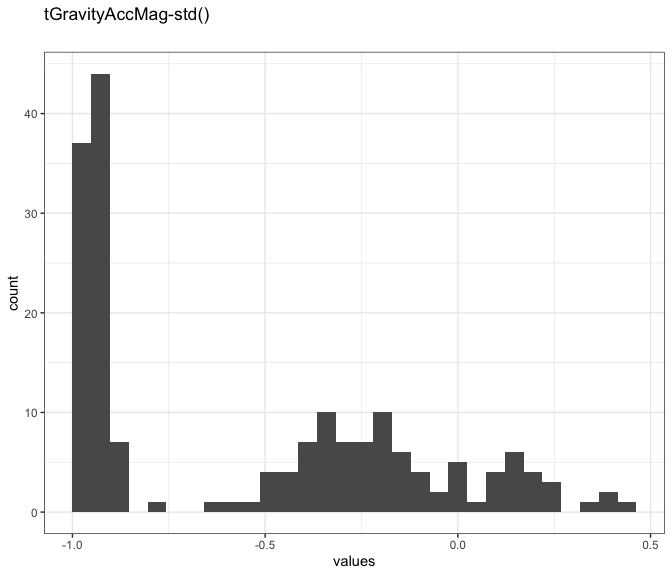

Distribution of values for tGravityAccMag-std()

0 missing values.

#### Summary statistics

| name | data_type | n_missing | complete_rate | min | median | max | mean | sd | hist | label |
| --- | --- | --- | --- | --- | --- | --- | --- | --- | --- | --- |
| tGravityAccMag-std() | numeric | 0 | 1 | -0.99 | -0.61 | 0.43 | -0.5439087 | 0.4310448 | ▇▁▅▂▁ | NA |

### tBodyAccJerkMag-mean()

#### Distribution

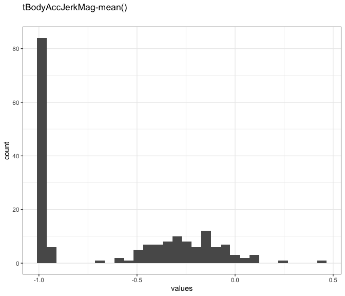

Distribution of values for tBodyAccJerkMag-mean()

0 missing values.

#### Summary statistics

| name | data_type | n_missing | complete_rate | min | median | max | mean | sd | hist | label |
| --- | --- | --- | --- | --- | --- | --- | --- | --- | --- | --- |
| tBodyAccJerkMag-mean() | numeric | 0 | 1 | -0.99 | -0.82 | 0.43 | -0.6079296 | 0.3965272 | ▇▂▅▂▁ | NA |

### tBodyAccJerkMag-std()

#### Distribution

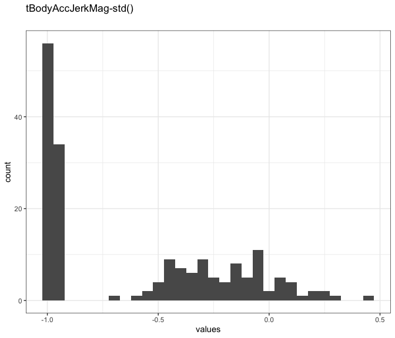

Distribution of values for tBodyAccJerkMag-std()

0 missing values.

#### Summary statistics

| name | data_type | n_missing | complete_rate | min | median | max | mean | sd | hist | label |
| --- | --- | --- | --- | --- | --- | --- | --- | --- | --- | --- |
| tBodyAccJerkMag-std() | numeric | 0 | 1 | -0.99 | -0.8 | 0.45 | -0.5841756 | 0.4227953 | ▇▂▃▂▁ | NA |

### tBodyGyroMag-mean()

#### Distribution

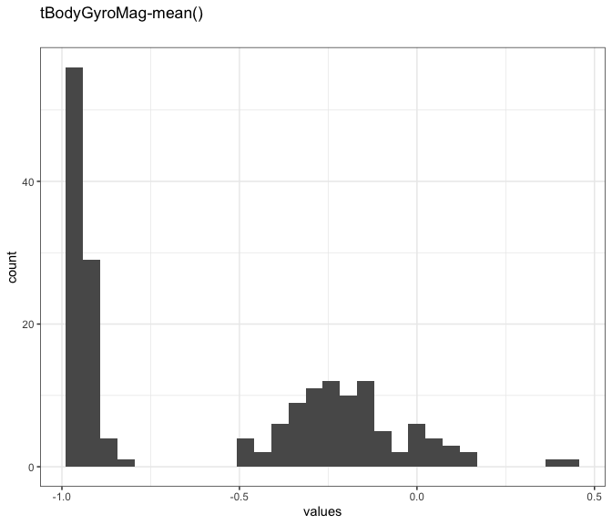

Distribution of values for tBodyGyroMag-mean()

0 missing values.

#### Summary statistics

| name | data_type | n_missing | complete_rate | min | median | max | mean | sd | hist | label |
| --- | --- | --- | --- | --- | --- | --- | --- | --- | --- | --- |
| tBodyGyroMag-mean() | numeric | 0 | 1 | -0.98 | -0.66 | 0.42 | -0.5651631 | 0.3977338 | ▇▁▅▂▁ | NA |

### tBodyGyroMag-std()

#### Distribution

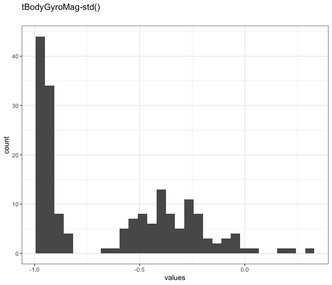

Distribution of values for tBodyGyroMag-std()

0 missing values.

#### Summary statistics

| name | data_type | n_missing | complete_rate | min | median | max | mean | sd | hist | label |
| --- | --- | --- | --- | --- | --- | --- | --- | --- | --- | --- |
| tBodyGyroMag-std() | numeric | 0 | 1 | -0.98 | -0.74 | 0.3 | -0.6303947 | 0.3368827 | ▇▂▅▂▁ | NA |

### tBodyGyroJerkMag-mean()

#### Distribution

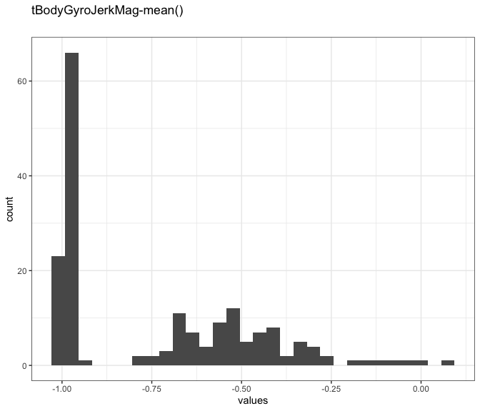

Distribution of values for tBodyGyroJerkMag-mean()

0 missing values.

#### Summary statistics

| name | data_type | n_missing | complete_rate | min | median | max | mean | sd | hist | label |
| --- | --- | --- | --- | --- | --- | --- | --- | --- | --- | --- |
| tBodyGyroJerkMag-mean() | numeric | 0 | 1 | -1 | -0.86 | 0.088 | -0.7363693 | 0.2767541 | ▇▃▃▁▁ | NA |

### tBodyGyroJerkMag-std()

#### Distribution

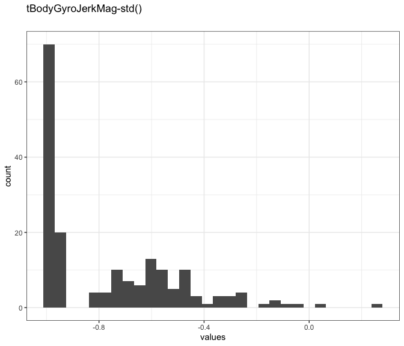

Distribution of values for tBodyGyroJerkMag-std()

0 missing values.

#### Summary statistics

| name | data_type | n_missing | complete_rate | min | median | max | mean | sd | hist | label |
| --- | --- | --- | --- | --- | --- | --- | --- | --- | --- | --- |
| tBodyGyroJerkMag-std() | numeric | 0 | 1 | -1 | -0.88 | 0.25 | -0.7550152 | 0.2655057 | ▇▃▂▁▁ | NA |

### fBodyAcc-mean()-X

#### Distribution

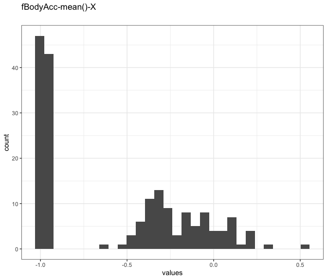

Distribution of values for fBodyAcc-mean()-X

0 missing values.

#### Summary statistics

| name | data_type | n_missing | complete_rate | min | median | max | mean | sd | hist | label |
| --- | --- | --- | --- | --- | --- | --- | --- | --- | --- | --- |
| fBodyAcc-mean()-X | numeric | 0 | 1 | -1 | -0.77 | 0.54 | -0.5758 | 0.4300214 | ▇▁▃▂▁ | NA |

### fBodyAcc-mean()-Y

#### Distribution

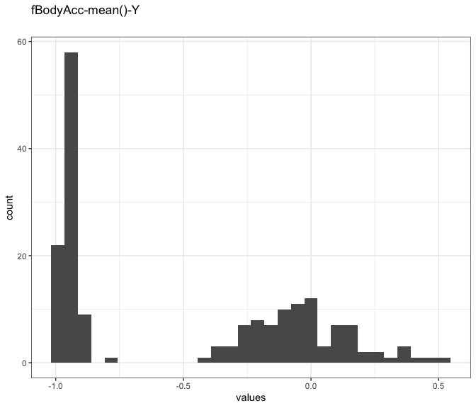

Distribution of values for fBodyAcc-mean()-Y

0 missing values.

#### Summary statistics

| name | data_type | n_missing | complete_rate | min | median | max | mean | sd | hist | label |
| --- | --- | --- | --- | --- | --- | --- | --- | --- | --- | --- |
| fBodyAcc-mean()-Y | numeric | 0 | 1 | -0.99 | -0.59 | 0.52 | -0.4887327 | 0.4806496 | ▇▁▃▃▁ | NA |

### fBodyAcc-mean()-Z

#### Distribution

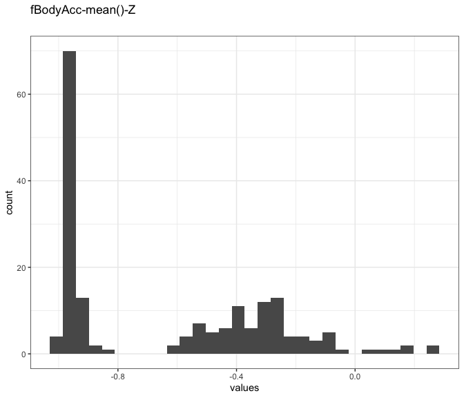

Distribution of values for fBodyAcc-mean()-Z

0 missing values.

#### Summary statistics

| name | data_type | n_missing | complete_rate | min | median | max | mean | sd | hist | label |
| --- | --- | --- | --- | --- | --- | --- | --- | --- | --- | --- |
| fBodyAcc-mean()-Z | numeric | 0 | 1 | -0.99 | -0.72 | 0.28 | -0.6297388 | 0.3556469 | ▇▂▅▁▁ | NA |

### fBodyAcc-std()-X

#### Distribution

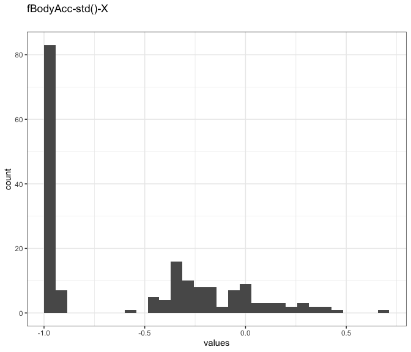

Distribution of values for fBodyAcc-std()-X

0 missing values.

#### Summary statistics

| name | data_type | n_missing | complete_rate | min | median | max | mean | sd | hist | label |
| --- | --- | --- | --- | --- | --- | --- | --- | --- | --- | --- |
| fBodyAcc-std()-X | numeric | 0 | 1 | -1 | -0.75 | 0.66 | -0.5522011 | 0.4600233 | ▇▂▅▂▁ | NA |

### fBodyAcc-std()-Y

#### Distribution

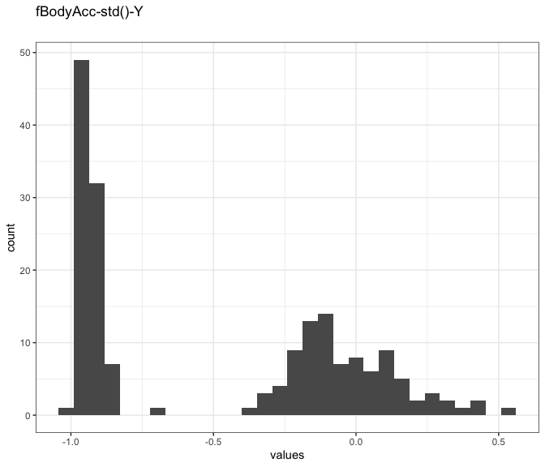

Distribution of values for fBodyAcc-std()-Y

0 missing values.

#### Summary statistics

| name | data_type | n_missing | complete_rate | min | median | max | mean | sd | hist | label |
| --- | --- | --- | --- | --- | --- | --- | --- | --- | --- | --- |
| fBodyAcc-std()-Y | numeric | 0 | 1 | -0.99 | -0.51 | 0.56 | -0.4814787 | 0.4740277 | ▇▁▅▃▁ | NA |

### fBodyAcc-std()-Z

#### Distribution

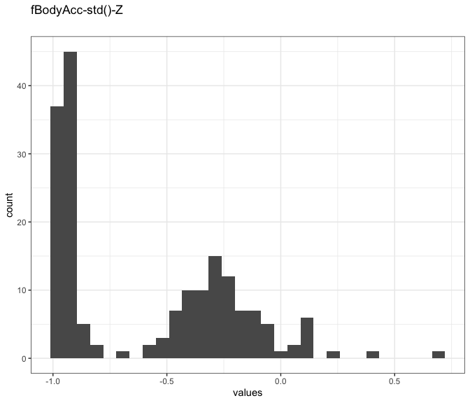

Distribution of values for fBodyAcc-std()-Z

0 missing values.

#### Summary statistics

| name | data_type | n_missing | complete_rate | min | median | max | mean | sd | hist | label |
| --- | --- | --- | --- | --- | --- | --- | --- | --- | --- | --- |
| fBodyAcc-std()-Z | numeric | 0 | 1 | -0.99 | -0.64 | 0.69 | -0.5823614 | 0.3880902 | ▇▃▅▁▁ | NA |

### fBodyAcc-meanFreq()-X

#### Distribution

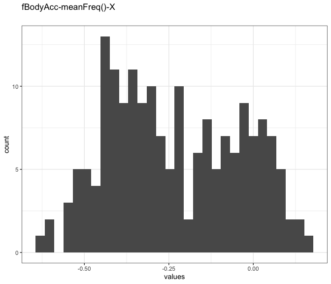

Distribution of values for fBodyAcc-meanFreq()-X

0 missing values.

#### Summary statistics

| name | data_type | n_missing | complete_rate | min | median | max | mean | sd | hist | label |
| --- | --- | --- | --- | --- | --- | --- | --- | --- | --- | --- |
| fBodyAcc-meanFreq()-X | numeric | 0 | 1 | -0.64 | -0.26 | 0.16 | -0.2322661 | 0.1935684 | ▂▇▆▆▃ | NA |

### fBodyAcc-meanFreq()-Y

#### Distribution

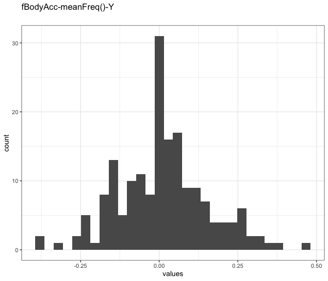

Distribution of values for fBodyAcc-meanFreq()-Y

0 missing values.

#### Summary statistics

| name | data_type | n_missing | complete_rate | min | median | max | mean | sd | hist | label |
| --- | --- | --- | --- | --- | --- | --- | --- | --- | --- | --- |
| fBodyAcc-meanFreq()-Y | numeric | 0 | 1 | -0.38 | 0.0079 | 0.47 | 0.0115289 | 0.1447051 | ▁▅▇▂▁ | NA |

### fBodyAcc-meanFreq()-Z

#### Distribution

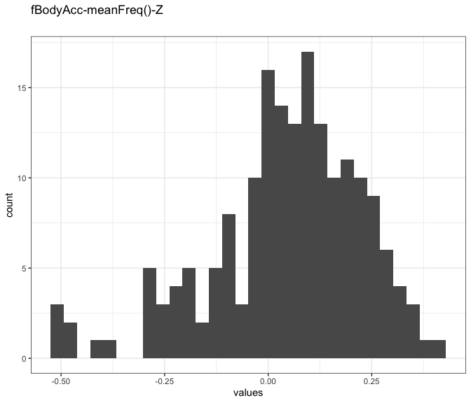

Distribution of values for fBodyAcc-meanFreq()-Z

0 missing values.

#### Summary statistics

| name | data_type | n_missing | complete_rate | min | median | max | mean | sd | hist | label |
| --- | --- | --- | --- | --- | --- | --- | --- | --- | --- | --- |
| fBodyAcc-meanFreq()-Z | numeric | 0 | 1 | -0.52 | 0.066 | 0.4 | 0.0437174 | 0.1850113 | ▁▂▆▇▃ | NA |

### fBodyAccJerk-mean()-X

#### Distribution

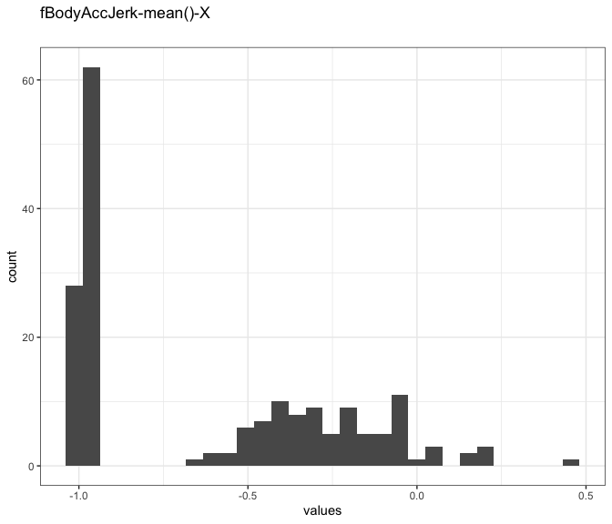

Distribution of values for fBodyAccJerk-mean()-X

0 missing values.

#### Summary statistics

| name | data_type | n_missing | complete_rate | min | median | max | mean | sd | hist | label |
| --- | --- | --- | --- | --- | --- | --- | --- | --- | --- | --- |
| fBodyAccJerk-mean()-X | numeric | 0 | 1 | -0.99 | -0.81 | 0.47 | -0.6139282 | 0.3982896 | ▇▂▃▂▁ | NA |

### fBodyAccJerk-mean()-Y

#### Distribution

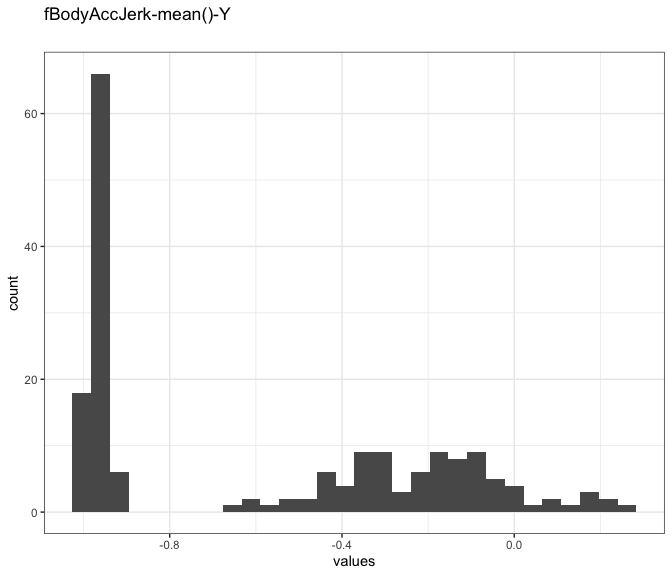

Distribution of values for fBodyAccJerk-mean()-Y

0 missing values.

#### Summary statistics

| name | data_type | n_missing | complete_rate | min | median | max | mean | sd | hist | label |
| --- | --- | --- | --- | --- | --- | --- | --- | --- | --- | --- |
| fBodyAccJerk-mean()-Y | numeric | 0 | 1 | -0.99 | -0.78 | 0.28 | -0.5881631 | 0.4077491 | ▇▁▃▃▁ | NA |

### fBodyAccJerk-mean()-Z

#### Distribution

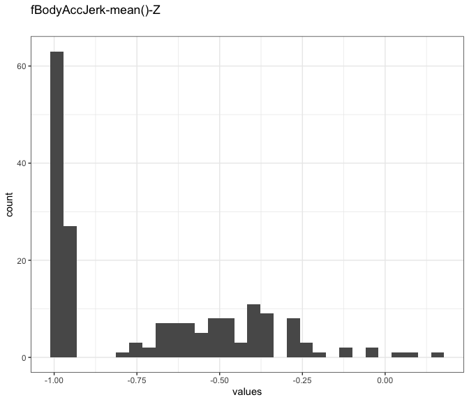

Distribution of values for fBodyAccJerk-mean()-Z

0 missing values.

#### Summary statistics

| name | data_type | n_missing | complete_rate | min | median | max | mean | sd | hist | label |
| --- | --- | --- | --- | --- | --- | --- | --- | --- | --- | --- |
| fBodyAccJerk-mean()-Z | numeric | 0 | 1 | -0.99 | -0.87 | 0.16 | -0.7143585 | 0.2970225 | ▇▂▃▁▁ | NA |

### fBodyAccJerk-std()-X

#### Distribution

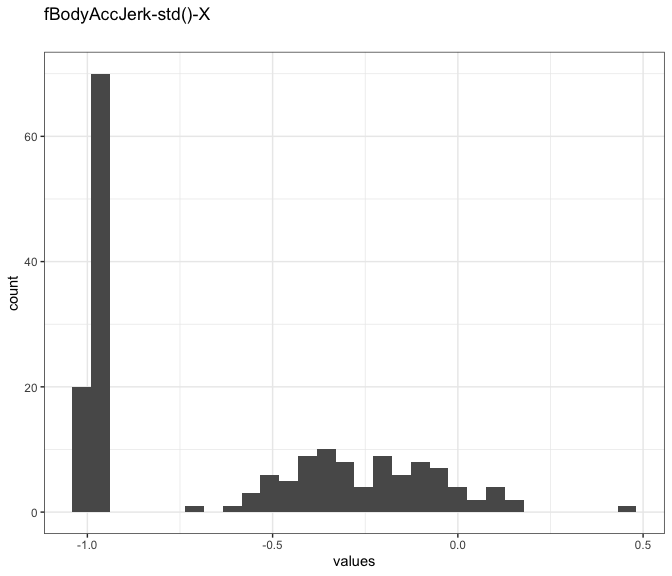

Distribution of values for fBodyAccJerk-std()-X

0 missing values.

#### Summary statistics

| name | data_type | n_missing | complete_rate | min | median | max | mean | sd | hist | label |
| --- | --- | --- | --- | --- | --- | --- | --- | --- | --- | --- |
| fBodyAccJerk-std()-X | numeric | 0 | 1 | -1 | -0.83 | 0.48 | -0.6121033 | 0.4004506 | ▇▂▃▂▁ | NA |

### fBodyAccJerk-std()-Y

#### Distribution

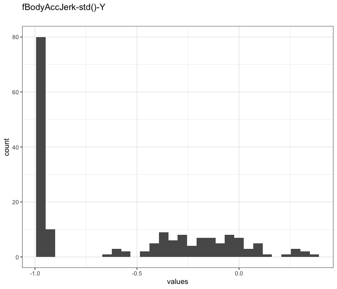

Distribution of values for fBodyAccJerk-std()-Y

0 missing values.

#### Summary statistics

| name | data_type | n_missing | complete_rate | min | median | max | mean | sd | hist | label |
| --- | --- | --- | --- | --- | --- | --- | --- | --- | --- | --- |
| fBodyAccJerk-std()-Y | numeric | 0 | 1 | -0.99 | -0.79 | 0.35 | -0.570731 | 0.4319873 | ▇▁▃▃▁ | NA |

### fBodyAccJerk-std()-Z

#### Distribution

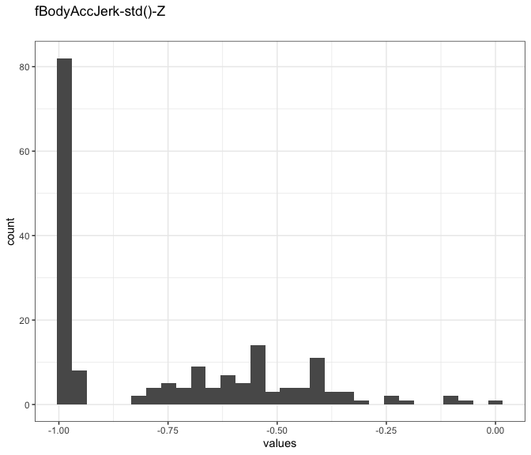

Distribution of values for fBodyAccJerk-std()-Z

0 missing values.

#### Summary statistics

| name | data_type | n_missing | complete_rate | min | median | max | mean | sd | hist | label |
| --- | --- | --- | --- | --- | --- | --- | --- | --- | --- | --- |
| fBodyAccJerk-std()-Z | numeric | 0 | 1 | -0.99 | -0.9 | -0.0062 | -0.7564894 | 0.2570577 | ▇▃▃▁▁ | NA |

### fBodyAccJerk-meanFreq()-X

#### Distribution

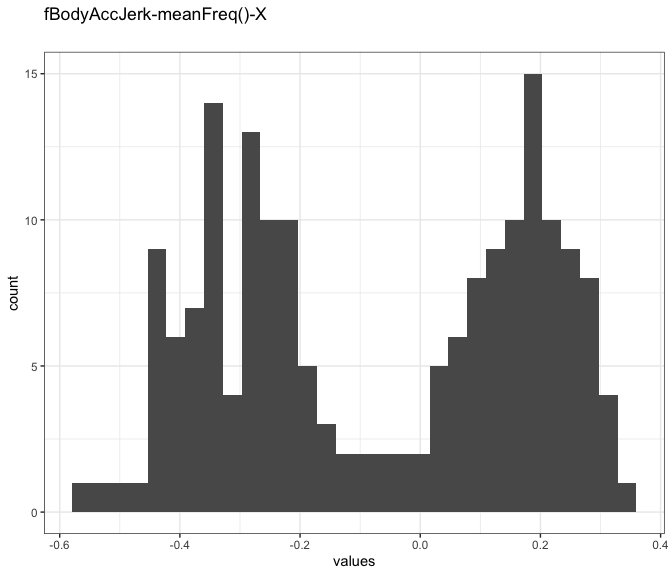

Distribution of values for fBodyAccJerk-meanFreq()-X

0 missing values.

#### Summary statistics

| name | data_type | n_missing | complete_rate | min | median | max | mean | sd | hist | label |
| --- | --- | --- | --- | --- | --- | --- | --- | --- | --- | --- |
| fBodyAccJerk-meanFreq()-X | numeric | 0 | 1 | -0.58 | -0.061 | 0.33 | -0.0691018 | 0.2541022 | ▂▇▂▅▇ | NA |

### fBodyAccJerk-meanFreq()-Y

#### Distribution

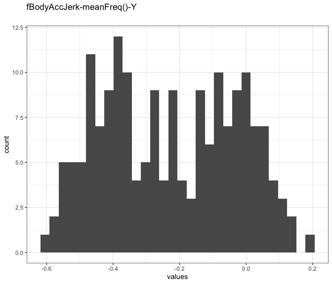

Distribution of values for fBodyAccJerk-meanFreq()-Y

0 missing values.

#### Summary statistics

| name | data_type | n_missing | complete_rate | min | median | max | mean | sd | hist | label |
| --- | --- | --- | --- | --- | --- | --- | --- | --- | --- | --- |
| fBodyAccJerk-meanFreq()-Y | numeric | 0 | 1 | -0.6 | -0.23 | 0.2 | -0.2281021 | 0.1998647 | ▅▇▆▇▃ | NA |

### fBodyAccJerk-meanFreq()-Z

#### Distribution

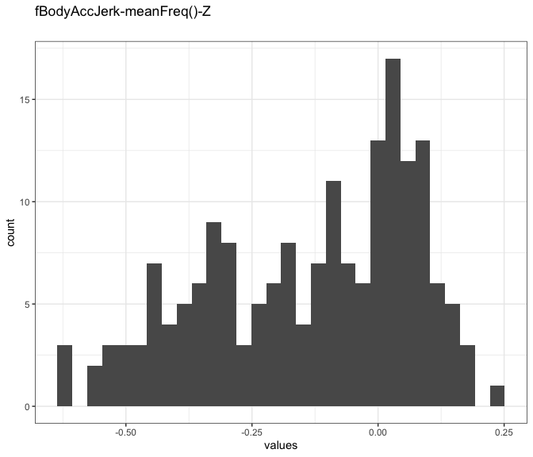

Distribution of values for fBodyAccJerk-meanFreq()-Z

0 missing values.

#### Summary statistics

| name | data_type | n_missing | complete_rate | min | median | max | mean | sd | hist | label |
| --- | --- | --- | --- | --- | --- | --- | --- | --- | --- | --- |
| fBodyAccJerk-meanFreq()-Z | numeric | 0 | 1 | -0.63 | -0.092 | 0.23 | -0.1376023 | 0.2078722 | ▂▅▃▇▅ | NA |

### fBodyGyro-mean()-X

#### Distribution

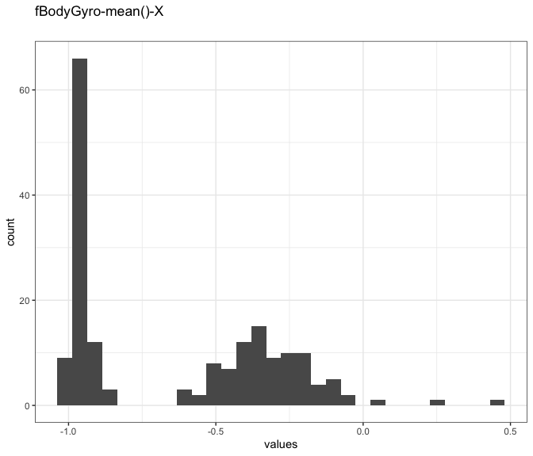

Distribution of values for fBodyGyro-mean()-X

0 missing values.

#### Summary statistics

| name | data_type | n_missing | complete_rate | min | median | max | mean | sd | hist | label |
| --- | --- | --- | --- | --- | --- | --- | --- | --- | --- | --- |
| fBodyGyro-mean()-X | numeric | 0 | 1 | -0.99 | -0.73 | 0.47 | -0.6367396 | 0.3467628 | ▇▂▅▁▁ | NA |

### fBodyGyro-mean()-Y

#### Distribution

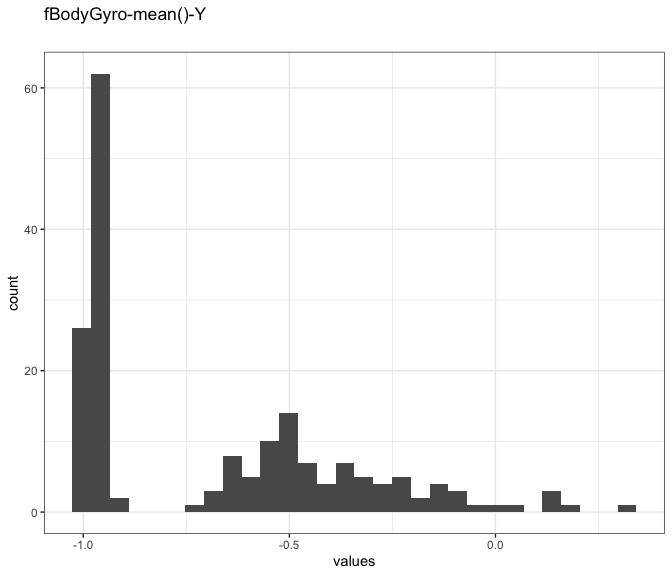

Distribution of values for fBodyGyro-mean()-Y

0 missing values.

#### Summary statistics

| name | data_type | n_missing | complete_rate | min | median | max | mean | sd | hist | label |
| --- | --- | --- | --- | --- | --- | --- | --- | --- | --- | --- |
| fBodyGyro-mean()-Y | numeric | 0 | 1 | -0.99 | -0.81 | 0.33 | -0.6766868 | 0.3319182 | ▇▃▃▁▁ | NA |

### fBodyGyro-mean()-Z

#### Distribution

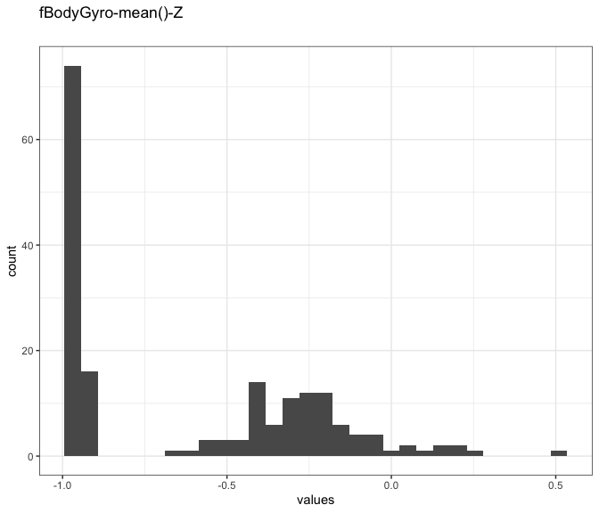

Distribution of values for fBodyGyro-mean()-Z

0 missing values.

#### Summary statistics

| name | data_type | n_missing | complete_rate | min | median | max | mean | sd | hist | label |
| --- | --- | --- | --- | --- | --- | --- | --- | --- | --- | --- |
| fBodyGyro-mean()-Z | numeric | 0 | 1 | -0.99 | -0.79 | 0.49 | -0.6043912 | 0.3842603 | ▇▂▅▁▁ | NA |